BACK TO MAIN MENU

- Introduction to Data Day 2
- Practice Activity

# Introduction to Data Day 2

### Get Your Document Ready

> Step 1: Open MS Word
- Start a blank document
- Click on INSERT > Header > Three Column Header
- Type your name, section, and instructor name *(A. Falchettore)* in the Header.

> Step 2: Save your Document
- FILE > SAVE AS
- Use the following format: your last name, your first initial, your student ID number, DD2. For example, if I am Sue Jones ID 99999999, my document would be saved as **joness99999999DD2**

### Get your Data Ready

> Step 3: Access Brightspace > Data Day
- Download the data file, but do not open it.

> Step 4: Start R GUI
- library(Rcmdr)

> Step 5: Import data
- Data > Import data > from Excel file

> Step 6: Read the instructions carefully and save often.

### The Edgar Anderson’s Iris Data

This famous *(Fisher’s or Anderson’s)* iris data set gives the measurements in centimeters of the variables sepal length and width and petal length and width, respectively, for 50 flowers from each of 3 species of iris. The species are Iris setosa, versicolor, and virginica.

**Petal:** One of the colored leaf-shaped parts of a flower.

**Sepal:** One of the small leaves that contains a young flower before the flower opens, and which stays directly under the flower.

**Open Data in R**

> Data > Data in packages > Read data set from an attached package

> Enter name of data set: iris

**Part A:** Choose one pair of variables. Make one scatterplot, calculate the correlation coefficient; then write one paragraph explaining the relationship, using your calculated correlation coefficient, and saying why you believe the relationship is a causal one *(one variable explains the data in the second variable)* or why you think the ‘relationship’ is not causal–that is, that there is another reason for the apparent relationship. If there is NO obvious relationship, explain why that is true.

The following output compares the flower sepal *(quantitative)* and petal length *(quantitative)*.

> Graphs > Scatterplot

> Choose x-variable: Sepal.length

> Choose y-variable: Petal.Length

> Click OK

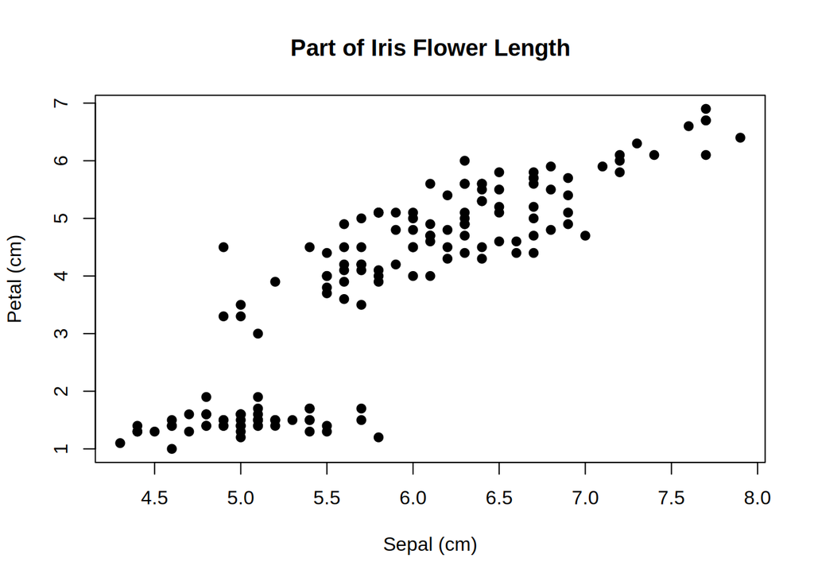

**Important:** Click on the OPTIONS tab to add axes labels and plot title.

> Statistics > Summaries > Correlation matrix

> Press the **Ctrl** and choose the variables: Sepal.Length and Petal.Length

> Click OK

```
[1] 0.8717538
```

**Part B:** Choose a second pair of variables. Make one graph showing side-by-side boxplot; then write one paragraph describing their relationship using the appropriate measures of center and spread and position, along with any skewing or outliers.

The following output compares the flower sepal length *(quantitative)* and specie type *(categorical)*

> Graphs > Boxplot > Variable: Sepal.Length

> Plot by groups > Group variable: Species > OK > OK

**Important:** Click on the OPTIONS tab to add axes labels and plot title.

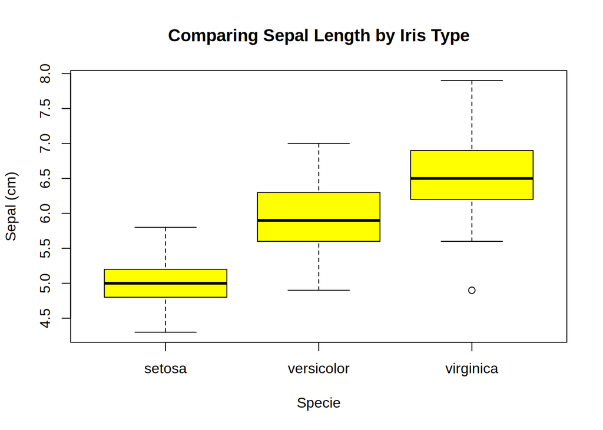

> Statistics > Summaries > Numerical summaries

> Variables: Sepal.Length

> Summarize by groups > Groups variable: Species > OK > OK

```
## $setosa
##    Min. 1st Qu.  Median    Mean 3rd Qu.    Max.
##   4.300   4.800   5.000   5.006   5.200   5.800
##
## $versicolor
##    Min. 1st Qu.  Median    Mean 3rd Qu.    Max.
##   4.900   5.600   5.900   5.936   6.300   7.000
##
## $virginica
##    Min. 1st Qu.  Median    Mean 3rd Qu.    Max.
##   4.900   6.225   6.500   6.588   6.900   7.900
```

**Part C:** Choose a third pair of variables and create one graph showing back-to-back stemplots; then write one paragraph describing their relationship using the appropriate measures of center and spread and position, along with any skewing or outliers.

The following output compares the flower petal length *(quantitative)* and specie type *(categorical)*

> Data > Active data set > Subset active data set

> Subset expression: **Species==“setosa” | Species==“virginica”** > OK > Yes

> Data > Manage variables in active data set > Drop unused factor levels

> Factor: **Species** > OK > OK

> Graphs > Stem-and-leaf display > Variable: Petal.Length

> Plot back-to-back by > Groups variable: Species > OK

```
_____________________________________________________________________________________________________________
  1 | 2: represents 1.2, leaf unit: 0.1
                                     petal_type[[1]]     petal_type[[3]]
_____________________________________________________________________________________________________________
  99777766666665555555555555444444444444433333332210| 1 |
                                                    | 2 |
                                                    | 3 |
                                                    | 4 |588999
                                                    | 5 |000111111122334455566666677788899
                                                    | 6 |00111346779
                                                    | 7 |
_____________________________________________________________________________________________________________
n:                                                50     50
_____________________________________________________________________________________________________________
```